# Paper Summary Assignment

Marqus Odisho & Sargon Yousefian

2024-12-13

### Paper Choice

*The physical environment mediates male harm and its effect on selection in females*. Li Yun, Patrick J. Chen, Amardeep Singh, Aneil F. Agrawal, and Howard D. Rundle.

### Methods Summary

#### Assay 1

This assay examined the impact of the physical environment on male fruit fly sexual behaviors. Two different environments were set up: a small vial and a larger Ziploc container, both containing food. Each environment had ten replicates, with 34 male and 34 female flies in each. The female flies were divided into two categories, small and large, based on manipulated egg density. For each replicate, four females, two large and two small, were marked with different fluorescent powders for identification. The flies were allowed to acclimate for one hour before observations began. Researchers recorded their movements three times a day (at 7:00, 12:00, and 17:00). During one-minute observation periods, the sexual activities directed toward each marked female were noted, including courtship behaviors like singing and chasing, as well as copulation attempts. The duration of these activities and whether the females fed during the observation were also recorded. Data from each arena were then aggregated for analysis. Sexual activity behaviour, and feeding observations were the response variables whereas the simple and complex environments were the predictor variables for this assay. A two-sample t-test was done to compare the difference in sexual activity score of the two female types between the two mating environments. Furthermore, a general linear model was used to analyze how feeding behaviour was influenced by mating arena, female size, and their interaction.

#### Assay 2

The second assay examined how environmental factors influence male-induced harm to female fruit flies through a two-way factorial experiment, manipulating male exposure (low vs. high) and environmental complexity, simple vs. complex. The simple environment was represented by vials, while the complex environment was represented by Ziploc containers. In total, 35 replicates were observed, each containing 35 female flies. In the low-exposure condition, females were exposed to males for three hours on days 1, 4, and 6 of their mating phase. In the high-exposure condition, males were present continuously in the arenas. After the third exposure, females were assessed for survival. From each replicate, ten random females were selected, and the number of adults or emerging pupae from their eggs was recorded. Total adult fitness, encompassing both fecundity and survival, was calculated by multiplying these two values. The response variable was total adult fitness and the predictor variables were the mating arena and male exposure type. A general linear model was used to determine the variation in total adult fitness with the fixed effects being mating arena, male exposure, and their interaction.

### Statistical Methods Summary

#### Assay 1

For this assay, two statistical methods were used to help interpret the results. First, a two-sample t-test treating separate mating arenas as replicates was conducted to compare the difference in sexual activity score of the two female types (large and small) between the two arenas. The reason the authors chose to create a sexual activity score and compare that across mating arenas was because the observations within a certain vial or cage were not independent. The results indicated that the means (difference in sexual activity) of the vial group and the cage group were significantly different as indicated by the values (t18 = 5.89, p < 0.001). To the authors this suggested that the difference in male sexual attention towards large and small females was different in vials vs. in cages. It made sense to use the two-sample t-test to compare means between the two environments, as one of the goals of this paper was to compare how the environment changed the sexual interactions of Drosophila melanogaster. It is also important to note that the authors took steps to avoid violating one of the assumptions of the two-sample t-test (independence) by creating a single sexual activity score for each replicate (for both small and large females) as the observations of average number of sexual encounters within the cages and vials were not independent. A general linear model was also used to analyze the influence of mating arena, female size, and their interaction on feeding observations. What the authors observed was that large females fed more often in cages than in vials whereas small females did not. This indicated that there was a significant interaction between mating arena and female size (F1,36 = 47.36, p < 0.001). The authors also found that feeding behaviours were higher in cages than vials when pooling across females (F1,36 = 21.30, p < 0.001). It made sense for the authors to use a general linear model as there were multiple independent variables and a single dependent variable (feeding). They also wanted to see how the independent variables interacted with each other to influence the feeding behaviours and they found a significant interaction between mating arena and female size. Similarly to the previous t-test, the goal of the general linear model was to determine the influence of the environment on female fruit flies when exposed to males.

#### Assay 2

The statistical method used for assay 2 was also a general linear model. This time the authors looked at the influence of mating arena, male exposure, and their interaction on total adult fitness of female fruit flies. What the authors found was that under lower male exposure, female fitness increased (F1,134 = 22.70, p < 0.0001). They also found that females in the complex cage arena had higher fitness than in vials (F1,134 = 110.43, p < 0.0001). Finally, the authors also concluded that there was a significant interaction between male exposure and mating arena suggesting that the impact of male exposure is higher in vials (F1,134 = 7.49, p < 0.007). The usage of the general linear model was a prudent one as it provided key information about male harm and how it is mediated by the environment which was a goal of this study. As there were multiple independent variables that could interact with each other to influence the predictor variable, it made sense to use a general linear model as the statistical methods.

### Data Simulation & Analysis

#### Assay 1

For the methods and results in Assay 1, the dataset was simulated and analysed corresponding to Figure 1a in the original paper. The corresponding code is separated into two blocks, one for Figure 1a simulation and the other for plotting. Note: Figure 1b is not shown as it had similar steps to Figure 2 which was also plotted and analyzed.

#### Figure 1a: Data Simulation and Analysis

```r
# Set the number of replicates from paper
n_vials <- 10

# Set the average differences in activity scores (this step was done in the paper without showing their work so this was an estimate of what they did)
mean_diff_simple <- 6
mean_diff_complex <- -1

# Adjust the standard deviation to achieve the desired t-value and p-value
sd_diff <- 2.5

# Create an empty data frame
activity_data <- data.frame(
  female_type = character(0),
  arena_type = character(0),
  vial_cage_id = numeric(0),
  activity_score = numeric(0)
)

# Generate data for each vial/cage, repeating until i = N of vials = which should be 10 (For loops are harder in R than in Python in my opinion!)
for (i in 1:n_vials) {
  # Simple arena
  activity_data <- rbind(activity_data, data.frame(
    female_type = "large",
    arena_type = "simple",
    vial_cage_id = i,
    activity_score = rnorm(1, mean = 10 + mean_diff_simple/2, sd = sd_diff) #
  ))
  activity_data <- rbind(activity_data, data.frame(
    female_type = "small",
    arena_type = "simple",
    vial_cage_id = i,
    activity_score = rnorm(1, mean = 10 - mean_diff_simple/2, sd = sd_diff)
  ))

  # Complex arena
  activity_data <- rbind(activity_data, data.frame(
    female_type = "large",
    arena_type = "complex",
    vial_cage_id = i,
    activity_score = rnorm(1, mean = 10 + mean_diff_complex/2, sd = sd_diff)
  ))
  activity_data <- rbind(activity_data, data.frame(
    female_type = "small",
    arena_type = "complex",
    vial_cage_id = i,
    activity_score = rnorm(1, mean = 10 - mean_diff_complex/2, sd = sd_diff)
  ))
}

# Calculate the difference in activity scores within each vial/cage
activity_data <- activity_data %>%
  group_by(arena_type, vial_cage_id) %>%
  summarize(score_difference = activity_score[female_type == "large"] - activity_score[female_type == "small"])
# Perform the two-sample t-test looking for difference in activity score between vial and cage groups
# Note: t-test should find a significant difference in means between the groups to match the value found in the paper. Approx t = 4
t.test(score_difference ~ arena_type, data = activity_data)
```

```
##
##  Welch Two Sample t-test
##
## data:  score_difference by arena_type
## t = -5.2379, df = 17.099, p-value = 6.558e-05
## alternative hypothesis: true difference in means between group complex and group simple is not equal to 0
## 95 percent confidence interval:
##  -13.613662  -5.798063
## sample estimates:
## mean in group complex  mean in group simple
##             -3.220779              6.485083
```

#### Figure 1a. Plot of Results

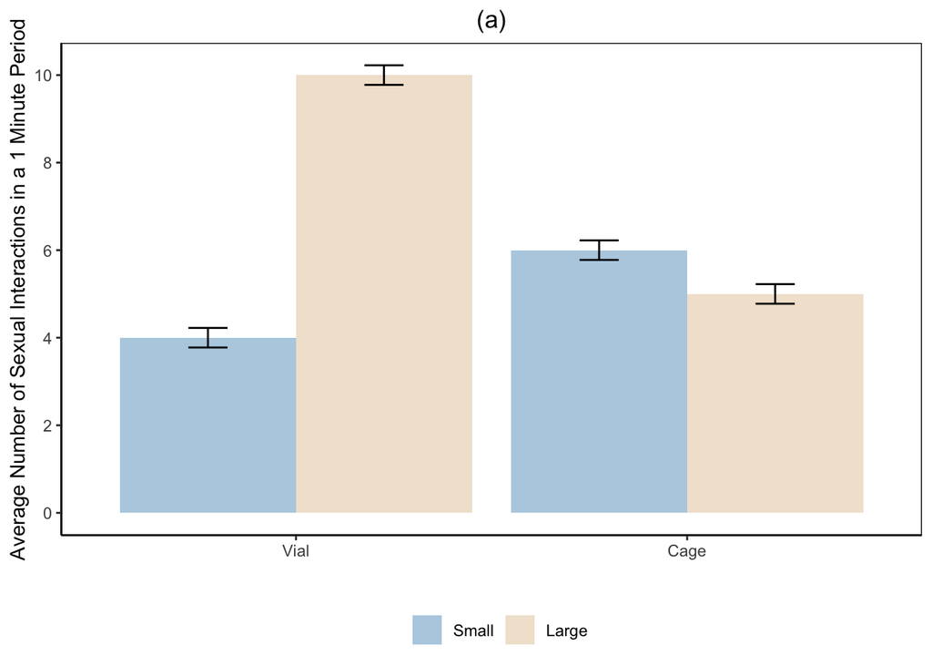

```r
# Code that generates a plot similar to figure 1a of the paper
# Data that is broken up into vial and cage with values for small females and large females.
data <- data.frame(
  Environment = factor(rep(c('Vial', 'Cage'), each = 2), levels = c('Vial', 'Cage')),
  Size = factor(rep(c('Small', 'Large'), 2), levels = c('Small', 'Large')),
  Mean = c(4, 10, 6, 5), # mean value of sexual interactions as found in the literature
  SD = c(1, 1, 1, 1)    # Standard deviation of 1 as a default as none was indicated in the paper
)

# Arena replicates of 10 of each mating arena = N of 20 to calculate standard error
n <- 20
data$SE <- data$SD / sqrt(n)  # Calculate Standard Error

# Create the bar graph with error bars (Environment on x-axis)
ggplot(data, aes(x = Environment, y = Mean, fill = Size)) +
  scale_y_continuous(breaks=c(0, 2, 4, 6, 8, 10)) +
  geom_bar(stat = 'identity', position = 'dodge') +
  geom_errorbar(aes(ymin = Mean - SE, ymax = Mean + SE),  # Use SE here
                width = 0.2, position = position_dodge(0.9)) +
  labs(
    title = '(a)',
    x = '',
    y = "Average Number of Sexual Interactions in a 1 Minute Period",
    fill = ' '
  ) +
  theme_classic() +
  theme(
    plot.title = element_text(hjust = 0.5),
    legend.position = 'bottom',
    panel.border = element_rect(colour = 'black', fill = NA)
  ) +
  scale_fill_manual(values = c('#B6D0E2', '#F1E3D3'))  # Pastel blue and yellow for the legend
```

#### Interpretation of Results in Figure 1a

The results indicated that the means (difference in sexual activity) of the vial group and the cage group were significantly different as indicated by the values (t18 = 5.89, p < 0.001). To the authors this suggested that the difference in male sexual attention towards large and small females was different in vials vs. in cages. Most of the increase in sexual attention was directed towards large females in vials.

#### Assay 2

Simulating and analyzing the data from Assay 2 which corresponds to figure 2 of the paper.

#### Figure 2: Data Simulation & Analysis

```r
# Simulating the data from Assay 2 of the paper that makes up figure 2. The analysis is the general linear model
# Simulated data following a normal distribution with an N of 35 matching that found in the paper. Mean is 1 so that it can be adjusted later to match the results of the paper.
low.vial <- rnorm(35, 1, 0.1)
high.vial <- rnorm(35, 1, 0.1)
low.cage <- rnorm(35, 1, 0.1)
high.cage <- rnorm(35, 1, 0.1)

# Combine into a single response variable
response <- c(
  24 * low.vial + rnorm(35, mean = 0, sd = 0.1),  # Low Vial with adjusted mean to match that found in paper
  17 * high.vial + rnorm(35, mean = 0, sd = 0.1), # High Vial with adjusted mean to match that found in paper
  30 * low.cage + rnorm(35, mean = 0, sd = 0.1),  # Low Cage with adjusted mean to match that found in paper
  28 * high.cage + rnorm(35, mean = 0, sd = 0.1)   # High Cage with adjusted mean to match that found in paper
)

# Divide data points in groups (low vs high) and type (vial vs cage)
data <- data.frame(
  response = response,
  group = factor(rep(c("Low", "High", "Low", "High"), each = 35)),
  type = factor(rep(c("Vial", "Vial", "Cage", "Cage"), times = 35))
  )

# Adjust to ensure proper pairing of group and type
data$type <- factor(rep(c("Vial", "Vial", "Cage", "Cage"), each = 35))

# Fit the two-way ANOVA model which shows similar results to the paper with lower fitness with higher male exposure and lower fitness in the vial groups
anova_model <- aov(response ~ group + type + group:type, data = data)

# Summary of the ANOVA
summary(anova_model)
```

```
##              Df Sum Sq Mean Sq F value   Pr(>F)
## group         1  519.8   519.8   79.05 3.27e-15 ***
## type          1 2213.8  2213.8  336.66  < 2e-16 ***
## group:type    1  186.2   186.2   28.32 4.13e-07 ***
## Residuals   136  894.3     6.6
## ---
## Signif. codes:  0 '***' 0.001 '**' 0.01 '*' 0.05 '.' 0.1 ' ' 1
```

#### Figure 2: Plot of Results

```r
# Simulated data following a normal distribution with an N of 35 matching that found in the paper. Mean is 1 so that it can be adjusted later to match the results of the paper.
low.vial <- rnorm(35, 1, 0.1)
high.vial <- rnorm(35, 1, 0.1)
low.cage <- rnorm(35, 1, 0.1)
high.cage <- rnorm(35, 1, 0.1)

# Combine into a single response variable
response <- c(
  24 * low.vial + rnorm(35, mean = 0, sd = 0.1),  # Low Vial with adjusted mean to match that found in paper
  17 * high.vial + rnorm(35, mean = 0, sd = 0.1), # High Vial with adjusted mean to match that found in paper
  30 * low.cage + rnorm(35, mean = 0, sd = 0.1),  # Low Cage with adjusted mean to match that found in paper
  28 * high.cage + rnorm(35, mean = 0, sd = 0.1)    # High Cage with adjusted mean to match that found in paper
)

# Divide data points in groups (low vs high) and type (vial vs cage) so that they can be ordered on the plot later
data <- data.frame(
  response = response,
  group = factor(rep(c("Low", "High", "Low", "High"), each = 35)),
  type = factor(rep(c("Vial", "Vial", "Cage", "Cage"), each = 35), levels = c("Vial", "Cage")) # Specify the order of levels
)

# Fit the two-way ANOVA model
anova_model <- aov(response ~ group + type + group:type, data = data)

# Summary of the ANOVA
summary(anova_model)
```

```
##              Df Sum Sq Mean Sq F value   Pr(>F)
## group         1  713.1   713.1  107.40  < 2e-16 ***
## type          1 2822.6  2822.6  425.08  < 2e-16 ***
## group:type    1  401.9   401.9   60.52 1.63e-12 ***
## Residuals   136  903.1     6.6
## ---
## Signif. codes:  0 '***' 0.001 '**' 0.01 '*' 0.05 '.' 0.1 ' ' 1
```

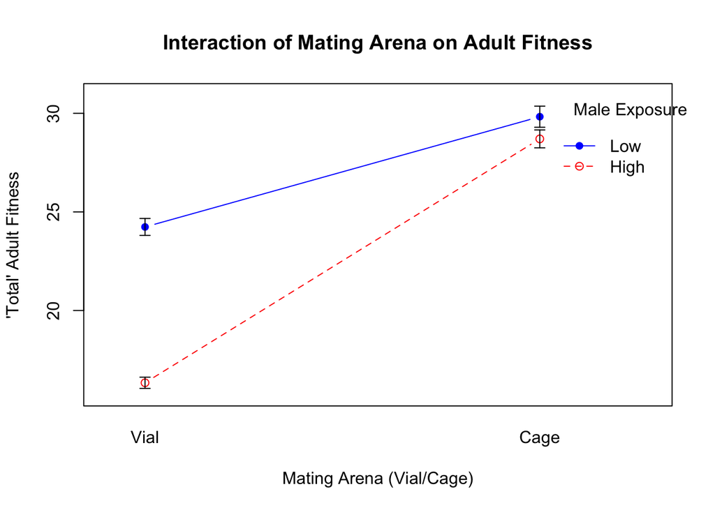

```r
# Calculate means and standard errors to be plotted
data_summary <- aggregate(response ~ group + type, data = data, FUN = function(x) c(mean = mean(x), se = sd(x)/sqrt(length(x))))
data_summary <- do.call(data.frame, data_summary)

# Create the interaction plot with error bars matching that found in figure 2 of the paper
interaction.plot(data_summary$type, data_summary$group, data_summary$response.mean,
                 type = "b", # "b" for both lines and points
                 pch = c(1,16), # Different point symbols
                 col = c("red","blue"), # Different colors for lines and points
                 xlab = "Mating Arena (Vial/Cage)",
                 ylab = "'Total' Adult Fitness",
                 trace.label = "Male Exposure",
                 main = "Interaction of Mating Arena on Adult Fitness",
                 ylim = c(min(data_summary$response.mean - 2*data_summary$response.se), max(data_summary$response.mean + 2*data_summary$response.se))) # Adjust ylim to accommodate error bars

# Error bars that match the standard error of 1 found in the paper's error bars.
arrows(x0 = as.numeric(data_summary$type), # Create error bars using the arrow function in r
       y0 = data_summary$response.mean - data_summary$response.se, # minus 1 se
       x1 = as.numeric(data_summary$type),
       y1 = data_summary$response.mean + data_summary$response.se, # plus 1 se
       length = 0.05, angle = 90, code = 3)
```

#### Interpretation of Results in Figure 2

From the ANOVA generated by the generalized linear model, both the P value comparing high versus low exposure and the vial versus the cage arena were lower than 0.05. This indicates that the there are significant differences between each treatment. Specifically, the statistical analysis reveals that a higher exposure to males leads to a reduced adult fitness. Furthermore, it also reveals that in the cage arena the females had a higher adult fitness than in the vial.